# User-provided functions

```r
library(HydroBOT)
library(dplyr)
library(ggplot2)
```

In most of the demonstrations, we have used some of the named functions provided by {HydroBOT} or those that are provided by R itself. However, it is possible for a user to develop custom functions and use those as well in the `funsequence` of `multi_aggregate()` and `read_and_agg()` (and in some other functions as well like `baseline_compare()` (see a contrived example). The most stable and best practice for specifying aggregation functions is to specify them as a named function, and supply that to the `funsequence`. See the aggregation syntax for a full treatment of the way functions can be specified. We demonstrate here with the best-supported method for with `read_and_agg()`, since that is the most common situation, but it also works with multi_aggregate.

As always, we need to point to the data.

```r
project_dir <- "hydrobot_scenarios"
hydro_dir <- file.path(project_dir, "hydrographs")
ewr_results <- file.path(project_dir, "module_output", "EWR")
agg_results <- file.path(project_dir, "aggregator_output", "demo")
```

## Defining functions

We demonstrate here with a threshold function and a slightly-modified median with `na.rm = TRUE`. For example, we might want to know the mean of all values greater than 0 for some stages and use the median at others.

```r
mean_given_occurred <- function(x) {
  mean(ifelse(x > 0, x, NA), na.rm = TRUE)
}

medna <- function(x) {
  median(x, na.rm = TRUE)
}
```

Now we can put those in the `funsequence`:

```r
aggseq_funs <- list(
  all_time = "all_time",
  ewr_code = c("ewr_code_timing", "ewr_code"),
  env_obj = c("ewr_code", "env_obj"),
  sdl_units = sdl_units,
  Target = c("env_obj", "Target")
)


funseq_funs <- list(
  all_time = "ArithmeticMean",
  ewr_code = "ArithmeticMean",
  env_obj = "mean_given_occurred",
  sdl_units = "medna",
  Target = "mean_given_occurred"
)
```

Those changes are then reflected in the aggregation history and determine the aggregated values.

```r
agged_custom_funs <- read_and_agg(
  datpath = ewr_results,
  type = "achievement",
  geopath = bom_basin_gauges,
  causalpath = causal_ewr,
  groupers = "scenario",
  aggCols = "ewr_achieved",
  group_until = list(
    SWSDLName = is_notpoint,
    planning_unit_name = is_notpoint,
    gauge = is_notpoint
  ),
  pseudo_spatial = "sdl_units",
  aggsequence = aggseq_funs,
  funsequence = funseq_funs,
  saveintermediate = TRUE,
  namehistory = FALSE,
  keepAllPolys = FALSE,
  returnList = TRUE,
  savepath = agg_results,
  add_max = FALSE
)
```

We can plot them to double check it worked.

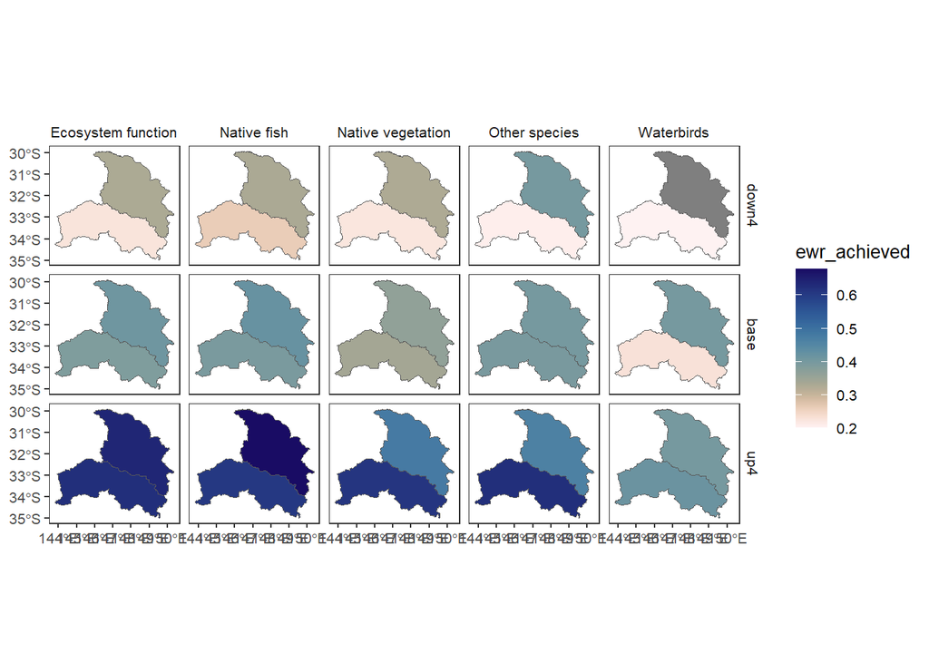

```r
agged_custom_funs$Target |>
  dplyr::filter(scenario != "MAX") |>
  plot_outcomes(
    outcome_col = "ewr_achieved",
    y_lab = "Arithmetic Mean",
    plot_type = "map",
    colorgroups = NULL,
    colorset = "ewr_achieved",
    pal_list = list("scico::lapaz"),
    pal_direction = -1,
    facet_col = "Target",
    facet_row = "scenario",
    sceneorder = c("down4", "base", "up4")
  )
```